```r
time = Sys.time()
```

# Modèle n°6 : Probit

$\\$

### Simulation.

1. Explain how to sample from the model. Code the procedure in a function rgen.

We have the following probit model :
$$P(Y=1|X=x)=\Phi(\alpha+\beta x ±\epsilon) \\
X \text{~ }\mathcal{U}(-1;\,1) \\
\epsilon \text{~ }\mathcal{N}(0,\,1) \\
\alpha \text{~}\mathcal{N}(0,\,1) ~~~~~~
\beta|X=x \text{ ~ }\mathcal{N}(0,\,\frac{n}{\sum_{i=1}^n x_i})$$
We have to fix a number n. Then we simulate the iid $(x_i)_{i=1...n}$ according to a uniform law on {-1,1}. We can now simulate the parameter $\epsilon$, $\alpha$ and $\beta$ according to their normal law. Finally, we simulate V an independant standard gaussian law and take y=1 if z<$\alpha$+$\beta$x+$\epsilon$, y=0 otherwise.

```r
rgen = function(n, model='first') { #generation of the data : n=number of observation, model : first for questions 1 to 8; second for the question 9

  if(model=='first'){
  x = sample(c(-1,1), n, replace=T) #sample x
  }
  else if(model=='second'){
    x = runif(n, min=-1, max=1)
  }
  eps = rnorm(n) # n independent noises
  alpha = rnorm(1, 0, 1) # 1 alpha simulated for the dataset
  beta = rnorm(1, 0, 1) # 1 beta simulated for the dataset
  y = 1*(rnorm(n)<alpha+beta*x+eps*1*(model=='first')) #sample y according the probit model

  return (rbind(x,y,alpha,beta))
}
```

$\\$

2. Data may contains noise, a systematic bias or missing/censored values. Give a function tr.dat which transforms a sample such that it has one or several of the aforementioned pecularities.

We create some biaises noise in the $x_i$’s by adding a normal(0.5, 1) law. We also keep only 95% of the dateset.

```r
tr.dat = function(sample){ #transformation of the x's : the model becomes a continuous probit model

  n = dim(sample)[2] # number of observation of the dataset
  keep = sample(1:n, 0.95*n, replace=F) # keep randomly only 95% of the data
  sample = sample[,keep]
  sample[1,] = sample[1,] + rnorm(0.95*n, 0.5,1) # add some noise with biais to the x's

  return (sample)
}
```

### Parameter inference.

$\\$

3. Explain how to infer model’s parameters with one or several simulation based approaches and give the corresponding code.

Let’s compute the posterior law of the parameters. It’s obvious that $\alpha$ and $\beta$ are not independant knowing (X, Y) since they are linked by $\Phi$ (but they stay independant without any conditionnal knowledge). So, we need to compute the posterior law of the couple. By denoting $p(X)$ the density of a random variabe X, we have by the bayes formula :

$$\begin{aligned}
p(\alpha, \beta|x,y,\epsilon) &\propto p(x,y|\alpha, \beta, \epsilon)p(\epsilon)p(\alpha)p(\beta)\\
&= p(y|x,\alpha, \beta, \epsilon)p(x|\alpha, \beta)p(\epsilon)p(\alpha)p(\beta) \\
&= p(y|x,\alpha, \beta, \epsilon)p(x)p(\epsilon)p(\alpha)p(\beta) \\
&\propto p(y|x,\alpha, \beta, \epsilon)p(\epsilon)p(\alpha)p(\beta) \\
\end{aligned}$$

But since $y|x,\alpha, \beta$ take values in {0,1}, it can be viewed as a bernouilli law with parameter $\Phi(\alpha+\beta x +\epsilon)$. Finally we have :

$$p(\alpha, \beta|x,y,\epsilon)=\frac{\prod_{i=1}^n \Phi(\alpha+\beta x_i +\epsilon_i)^{y_i} (1-\Phi(\alpha+\beta x_i +\epsilon_i))^{1-y_i} p(\epsilon)p(\alpha)p(\beta)}{\int\int\prod_{i=1}^n \Phi(\alpha+\beta x_i +\epsilon_i)^{y_i} (1-\Phi(\alpha+\beta x_i +\epsilon_i))^{1-y_i} p(\epsilon)p(\alpha)p(\beta) \, \mathrm d\alpha d\beta}$$
We can see that the posterior law is quite complicated because of the non-linear function $\Phi$ and the constante normalization that don’t have a closed form. We are goning to overcome this problem by introducing a second equivalent model.

The probit model can be review into an equivalent model by adding a latent variable Z. Indeed, we have : $P(Y=1|X=x)=P(V<\alpha+\beta x+\epsilon)\underset{-V\text{~}V}{=}P(0<\alpha+\beta x+\epsilon+V):=P(Z>0)$ with $Z=\alpha+\beta x+\epsilon+V$ and $V\text{~}\mathcal{N}(0,\,1)$. Thus we have : y=$\mathbb{1}_{z>0}$

If we can determine the conditional law $z|(\alpha, \beta), y, x$ and $(\alpha, \beta)|z,y,x$, we could then sample from the law $z, (\alpha, \beta)|y,x$ and so from the marginal $(\alpha, \beta)|y,x$ which is the posterior law needed.

Firstly, by linearity and independance of V and $\epsilon$ : $z|(\alpha, \beta), x$~$\mathcal{N}(\alpha + \beta x,\,2)$. Then on the event {y=1}={z>0}, $z|(\alpha, \beta), x$ ~ $\mathcal{TN}(\alpha + \beta x,\,2, 0, \infty)$ and on the event {y=0}={z<0}, $z|(\alpha, \beta), x$ ~ $\mathcal{TN}(\alpha + \beta x,\,2, -\infty, 0)$ with $\mathcal{TN}$ denoting the truncated normal law with the last two parameters corresponding to the truncation bound. We can rewrite the final conditionnal law :
$$z|(\alpha, \beta), y, x\text{ ~ } y\mathcal{TN}(\alpha + \beta x,\,2, 0, \infty) + (1-y)\mathcal{TN}(\alpha + \beta x,\,2, -\infty, 0)$$
Secondly, we want to compute the law $(\alpha, \beta)|z,y,x$. We can first notice that knowing z, y is determinist (y=$\mathbb{1}_{z>0}$) and thus independant of $(\alpha, \beta)$. Then we obtain using the prior law given in the subject :

$$\begin{aligned}
p((\alpha, \beta)|z,y,x) &= p(\alpha, \beta|z,x)\\
&\propto p(z,x|\alpha, \beta)p(\alpha, \beta) \\
&= p(z|\alpha, \beta, x)p(x|\alpha, \beta)p(\alpha, \beta) \\
&= p(z|\alpha, \beta, x)p(\alpha, \beta|x)p(x) \\
&\propto \prod_{i=1}^n p(z_i|\alpha, \beta, x_i)p(\alpha)p(\beta|x_i) \\
&\propto \exp{-\frac{1}{2}(\sum_{i=1}^n\frac{(z_i-(\alpha + \beta x_i))^2}{2}+ \alpha^2 + \beta^2\overline{x}) } \\
&= \exp{-\frac{1}{2}(\sum_{i=1}^n \frac{z_i^2+\alpha^2 + \beta^2 x_i^2 + 2\alpha \beta x_i -2z_i(\alpha +\beta x_i)}{2}+ \alpha^2 + \beta^2\overline{x}) } \\
&\propto \exp{-\frac{1}{2}(\alpha^2(\frac{n}{2}+1) + \beta^2(\frac{\sum_{i=1}^nx_i^2}{2}+\overline{x}) + \frac{\alpha \beta \sum_{i=1}^n x_i}{2} + \frac{\beta \alpha \sum_{i=1}^n x_i}{2} -\sum_{i=1}^n z_i(\alpha +\beta x_i)) } \\
&= \exp{-\frac{1}{2}((\alpha ~~~ \beta) A (\alpha ~~~ \beta)^T -2(\alpha ~~~ \beta)AA^{-1}(\frac{\sum_{i=1}^n z_i}{2} ~~\frac{\sum_{i=1}^n z_ix_i}{2})^T ) } \\
\end{aligned}$$
We recognize a multidimensionnal law :
$$p((\alpha, \beta)|z,y,x) \text{ ~ } \mathcal{N}(A^{-1}(\frac{\sum_{i=1}^nz_i}{2} ~~\frac{\sum_{i=1}^nz_ix_i}{2})^T,\,A^{-1}) ~~\text{ with } A=
\begin{pmatrix}
\frac{n}{2}+1 & \frac{\sum_{i=1}^nx_i}{2} \\
\frac{\sum_{i=1}^nx_i}{2} & \frac{\sum_{i=1}^nx_i^2}{2}+\overline{x}
\end{pmatrix}$$
We can now simulate using gibbs sampling method with the two conditionnal law to obtain the posterior law of the parameters

```r
# Library for multidimensionnal normal law
library(MASS)
# Library for truncated normal law
library(truncnorm)

infer.gibss = function(sample, prior_mean, prior_var, model='first'){ #model : 'first' for the question 1 to 8; 'second' for the question 9

  N = 10^4 #number of simulations for gibbs sampler
  n = dim(sample)[2] #number of observation of the dataset
  x = sample[1,]
  y = sample[2,]
  if(model=='first'){
    A = matrix(c(n/2 +1/prior_var[1], sum(x)/2, sum(x)/2, sum(x^2)/2+ 1/prior_var[2]), nrow=2, ncol=2, byrow=T) # covariance matrix of the conditionnal law (alpha, beta) |z, x, y
  }
  else if(model=='second'){ #remove the factor 1/2
    A = matrix(c(n +1/prior_var[1], sum(x), sum(x), sum(x^2)+ 1/prior_var[2]), nrow=2, ncol=2, byrow=T) # covariance matrix of the conditionnal law (alpha, beta) |z, x, y
  }
  A_inv = solve(A) #inverse of A

  #initialization of the parameters
  z = rep(0, n)
  gibbs_alpha = rep(0,N)
  gibbs_beta = rep(0,N)

  for (i in 2:N) {

    #sample from z|alpha, beta x, y :

    mu = gibbs_alpha[i-1] + gibbs_beta[i-1]*x #mean of the conditionnal law
    TP = sum(y) # true positif = number of y such that y=1
    if(TP==0){ #check if all the y=0
      z = rtruncnorm(n, mean=mu, sd=1+1*(model=='first'), a=-Inf, b=0) #sd=2 if model=='first' else sd=2
    }
    else if(TP==n){ #check if all the y=1
      z = rtruncnorm(n, mean=mu, sd=1+1*(model=='first'), a=0, b=Inf) #sd=2 if model=='first' else sd=2
    }
    else{
      z[y == 0] = rtruncnorm(n-TP, mean=mu[y == 0], sd=1+1*(model=='first'), a=-Inf, b=0)
      z[y == 1] = rtruncnorm(TP, mean=mu[y == 1], sd=1+1*(model=='first'), a=0, b=Inf)
    }

    #sample from (alpha, beta)|z, x, y :

    if(model=='first'){
      B = c(sum(z)/2 +prior_mean[1]/prior_var[1], sum(z*x)/2 +prior_mean[2]/prior_var[2])
    }
    else if(model=='second'){ #remove the factor 1/2
      B = c(sum(z) +prior_mean[1]/prior_var[1], sum(z*x) +prior_mean[2]/prior_var[2])
    }
    res = mvrnorm(1, A_inv%*%B, A_inv)

    #keep the value sampled
    gibbs_alpha[i] = res[1]
    gibbs_beta[i] = res[2]
  }

  # create a dataframe with columns value (of the gibbs method) and label (alpha or beta). This kind of form will help us later for the plotting part
  alpha = data.frame(value=gibbs_alpha) #create a dataframe for alpha's values
  beta = data.frame(value=gibbs_beta) #create a dataframe for beta's values
  alpha$label = 'alpha' #add its label
  beta$label = 'beta' #add its label
  parameter = data.frame(rbind(alpha, beta)) #create a final dataframe with columns value and label

  return (parameter)
}
```

$\\$

Perform the analysis for the following situations:

4. a n-sample from the model with n = 20
5. a n-sample from the model with n = 500
6. a n-sample from the model, with n = 20, which exhibits one or several of the aforementioned pecularities
7. a n-sample from the model, with n = 500, which exhibits one or several of the aforementioned pecularities.

```r
library('ggplot2') #graphical library

#First, let's define three plot functions for the histogramme, mean estimator and autocorrelation :

plot_hist = function(parameter){ #function to plot histogramme of alpha and beta in the same graph

  ggplot(parameter, aes(x=value, color=label, fill=label)) +
  geom_histogram(aes(y=..density..), position="identity", alpha=0.5)+
  geom_density(alpha=0.6)+
  scale_color_manual(values=c("#999999", "#E69F00", "#56B4E9"))+
  scale_fill_manual(values=c("#999999", "#E69F00", "#56B4E9"))+
  labs(title="Parameters histogram plot",x="Values", y = "Density")+
  theme_classic()
}

plot_mean = function(parameter, true_alpha, true_beta){ #function to plot the convergence of the mean of alpha and beta

  n = length(parameter$value)/2 # number of observation (values of alpha and beta ==> 2n)

  mean_alpha = cumsum(parameter$value[parameter['label']=='alpha'])/(1:n)#convergence of the mean of alpha
  mean_beta = cumsum(parameter$value[parameter['label']=='beta'])/(1:n) #convergence of the mean of beta

  plot(mean_alpha,xlab="Number of simulations", ty="l", ylab="mean estimation", col="red", ylim=c(min(c(mean_alpha, mean_beta, true_alpha, true_beta)),max(c(mean_alpha, mean_beta, true_alpha, true_beta)))) #convergence of the mean estimators
  lines(mean_beta, col="purple")

  lines(rep(true_alpha, n), col="green") #true value of alpha
  lines(rep(true_beta, n), col="green") #true value of beta
  text(x=c(0.85*n, 0.85*n), y=c(true_alpha, true_beta), pos=4, labels=c('true alpha', 'true beta'))
  legend("center", legend=c("alpha estimator", "beta estimator"), col=c("red", "purple"), lty=c(1,1))
}

plot_autocorrelation = function(parameter){

  n = length(parameter$value)/2 # number of observation (values of alpha and beta ==> 2n)

  AutoCorrelation = acf(parameter$value[parameter['label']=='alpha'], plot=F)
  plot(AutoCorrelation, main="alpha")
  AutoCorrelation = acf(parameter$value[parameter['label']=='beta'], plot=F)
  plot(AutoCorrelation, main="beta")
}
```

```r
#Let's generate our 2 dataset :
set.seed(42) #to reproduce the result

sample_20 = rgen(20) #dataset with n=20
sample_500 = rgen(500) #dataset with n=500

prior_mean_20 = c(0,0) #prior mean of the first dataset
prior_mean_500 = c(0,0) #prior mean of the second dataset
prior_var_20 = c(1,500/(1+abs(sum(sample_20[1,])))) #prior variance of the first dataset
prior_var_500 = c(1,500/(1+abs(sum(sample_500[1,])))) #prior variance of the second dataset
```

### A n-sample from the model, with n = 20

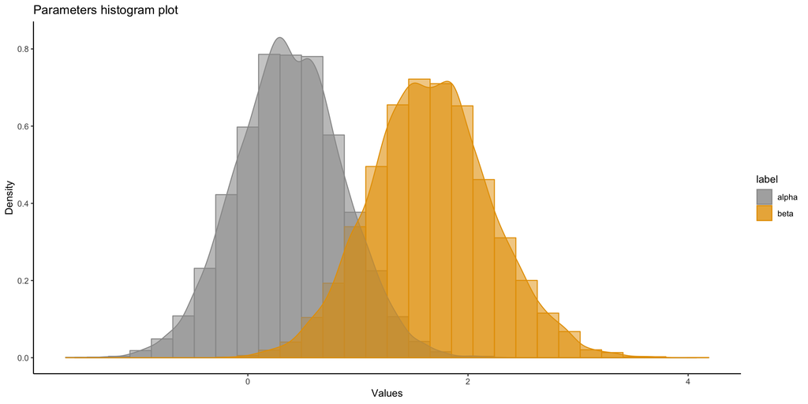

Figure 1: histogramme

```r
#Then, plot the different results :

parameter = infer.gibss(sample_20, prior_mean_20, prior_var_20) #run gibbs sampling
plot_hist(parameter) #plot the histogramme
```

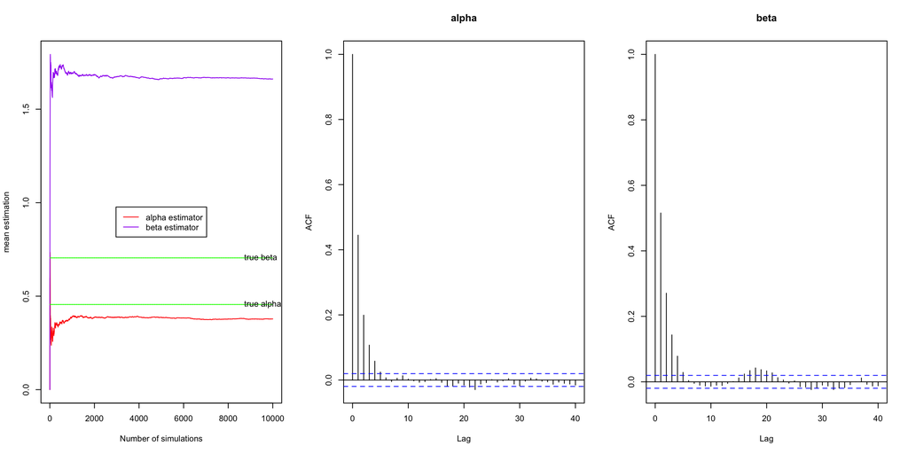

Figure 2: mean convergence and autocorrelation function

```r
par(mfrow = c(1, 3)) #three graphics in the same line
plot_mean(parameter, sample_20[3], sample_20[4]) #plot the convergence of the mean through simulation
plot_autocorrelation(parameter)
```

### A n-sample from the model, with n = 500

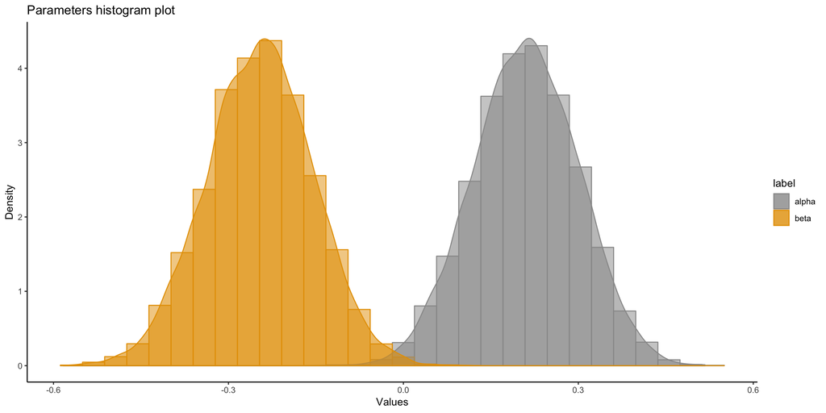

Figure 3: histogramme

```r
parameter = infer.gibss(sample_500, prior_mean_500, prior_var_500)
plot_hist(parameter) #plot the histogramme
```

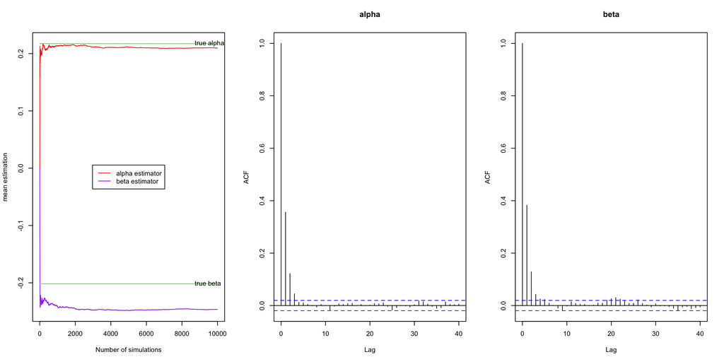

Figure 4: mean convergence and autocorrelation function

```r
par(mfrow = c(1, 3)) #three graphics in the same line
plot_mean(parameter, sample_500[3], sample_500[4]) #plot the convergence of the mean through simulation
plot_autocorrelation(parameter)
```

### A n-sample from the model, with n = 20, which exhibits one or several of the aforementioned pecularities

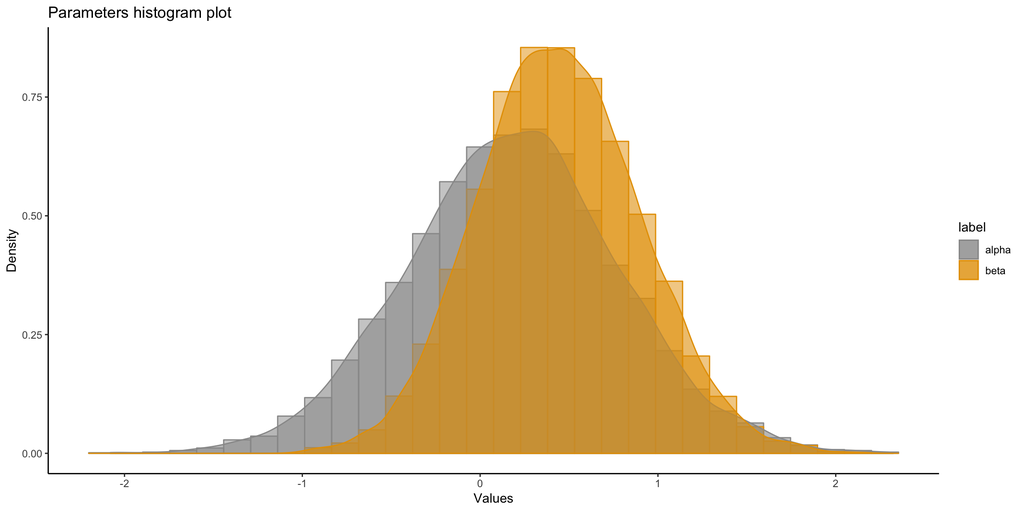

Figure 5: histogramme

```r
parameter = infer.gibss(tr.dat(sample_20), prior_mean_20, prior_var_20)
plot_hist(parameter) #plot the histogramme
```

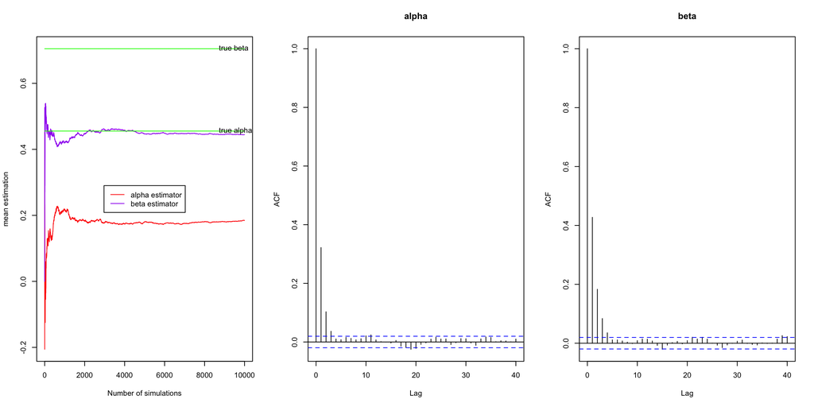

Figure 6: mean convergence and autocorrelation function

```r
par(mfrow = c(1, 3)) #three graphics in the same line
plot_mean(parameter, sample_20[3], sample_20[4]) #plot the convergence of the mean through simulation
plot_autocorrelation(parameter)
```

### A n-sample from the model, with n = 500, which exhibits one or several of the aforementioned pecularities

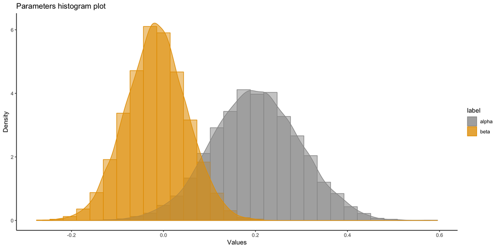

Figure 7: histogramme

```r
parameter = infer.gibss(tr.dat(sample_500), prior_mean_500, prior_var_500)
plot_hist(parameter) #plot the histogramme
```

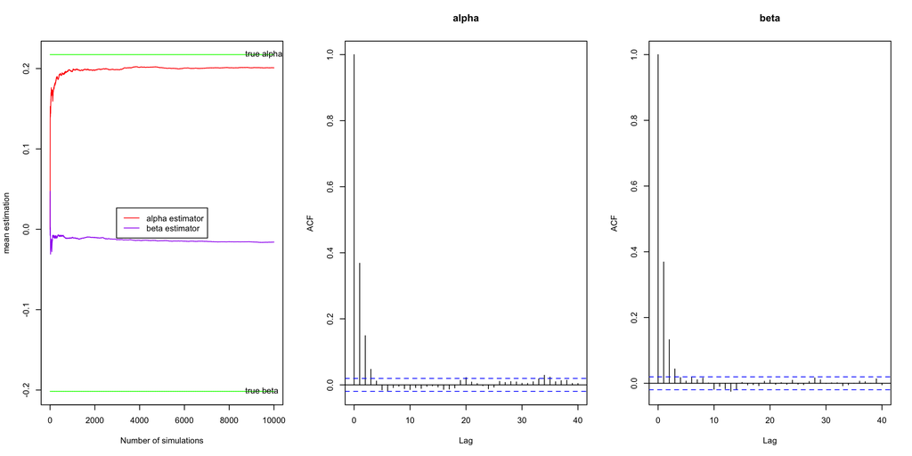

Figure 8: mean convergence and autocorrelation function

```r
par(mfrow = c(1, 3)) #three graphics in the same line
plot_mean(parameter, sample_500[3], sample_500[4]) #plot the convergence of the mean through simulation
plot_autocorrelation(parameter)
```

We can notice first that the posterior laws in the 4 cases seem to follow a noramle law according to the figures 1, 3, 5, 7. This is consistent with the fact that the normal law family is a natural conjugate law (same prior and posterior law).

Moreover, the simulations of the posterior laws have a low correlation that dissipates quickly through the time (2, 4, 6, 8). This explains the speed convergences of the average estimators as well as their quality (almost iid samples).

When the dataset has not been modified, we can compare the convergence of the average estimators of $\alpha$ and $\beta$. We observe that for n = 20 observations, the average estimator of $\alpha$ and $\beta$ don’t converge to their true value (2). For n = 500, both the convergence for alpha and beta estimator improved (4).

When the dataset has been modified, the estimation of the parameter will be obviously different from what is expected. But we can notice that the estimation of $\alpha$ remains still close to the true value for n = 500, whereas the estimation of $\beta$ moved. This is due to the specification of the model where $\beta$ is linked with x (which has been changed with biai).

Further analysis shows that these estimator are very dependant to the initialization value in the gibbs algorithm.

$\\$

8. Test the sensitivity of the prior by modifying one or several components.

Recall that we have $\alpha \text{~}\mathcal{N}(0,\,1)$ and $\beta|x \text{~}\mathcal{N}(0,\,\frac{n}{\sum_{i=1}^nx_i})$ as a prior law. We are now considering $\alpha \text{~}\mathcal{N}(\mu_1,\,\sigma_1^2)$ and $\beta \text{~}\mathcal{N}(\mu_2,\,\sigma_2^2)$.

In the gibbs sampling method, we could determine the posterior laws of the parameter thanks to $z|(\alpha, \beta), y, x$ and $(\alpha, \beta)|z,y,x$. The former conditionnal law remains the same as previously since it doesn’t depend on the prior laws whereas the latter depend on the prior laws, and we have :

$$\begin{aligned}
p((\alpha, \beta)|z,y,x) &= p(\alpha, \beta|z,x)\\
&\propto p(z,x|\alpha, \beta)p(\alpha, \beta) \\
&= p(z|\alpha, \beta, x)p(x|\alpha, \beta)p(\alpha, \beta) \\
&= p(z|\alpha, \beta, x)p(x)p(\alpha, \beta) \\
&= \prod_{i=1}^n p(z_i|\alpha, \beta, x_i)p(\alpha)p(\beta) \\
&\propto \exp{-\frac{1}{2}(\sum_{i=1}^n\frac{(z_i-(\alpha + \beta x_i))^2}{2}+ \frac{(\alpha-\mu_1)^2}{\sigma_1^2} + \frac{(\beta-\mu_2)^2}{\sigma_2^2}) } \\
&\propto \exp{-\frac{1}{2}(\alpha^2(\frac{n}{2}+\frac{1}{\sigma_1^2}) + \beta^2(\frac{\sum_{i=1}^nx_i^2}{2}+\frac{1}{\sigma_2^2}) + \frac{\alpha \beta \sum_{i=1}^n x_i}{2} + \frac{\beta \alpha \sum_{i=1}^n x_i}{2} -\sum_{i=1}^n z_i(\alpha +\beta x_i) -2\alpha\frac{\mu_1}{\sigma_1^2}-2\beta\frac{\mu_2}{\sigma_2^2}) } \\
&= \exp{-\frac{1}{2}((\alpha ~~~ \beta) A (\alpha ~~~ \beta)^T -2(\alpha ~~~ \beta)AA^{-1}(\frac{\sum_{i=1}^n z_i}{2}+\frac{\mu_1}{\sigma_1^2} ~~~~~~\frac{\sum_{i=1}^n z_ix_i}{2}+\frac{\mu_2}{\sigma_2^2})^T ) } \\
\end{aligned}$$
We recognize a multidimensionnal law :
$$p((\alpha, \beta)|z,y,x) \text{ ~ } \mathcal{N}(A^{-1}(\frac{\sum_{i=1}^n z_i}{2}+\frac{\mu_1}{\sigma_1^2} ~~~~~~\frac{\sum_{i=1}^n z_ix_i}{2}+\frac{\mu_2}{\sigma_2^2})^T,\,A^{-1}) ~~\text{ with } A=
\begin{pmatrix}
\frac{n}{2}+\frac{1}{\sigma_1^2} & \frac{\sum_{i=1}^nx_i}{2} \\
\frac{\sum_{i=1}^nx_i}{2} & \frac{\sum_{i=1}^nx_i^2}{2}+\frac{1}{\sigma_2^2}
\end{pmatrix}$$
Then, we can rerun the previous gibbs algorithm with the new conditionnal law. We have choose 3 different parameters of the normal prior laws :

- $\mu_1=\mu_2=0 ~~~~~~~~ \sigma_1=\sigma_2=1$
- $\mu_1=\mu_2=5 ~~~~~~~~ \sigma_1=\sigma_2=2$
- $\mu_1=-2 ~~ \mu_2=2 ~~~~~~~~ \sigma_1=1 ~~ \sigma_2=3$

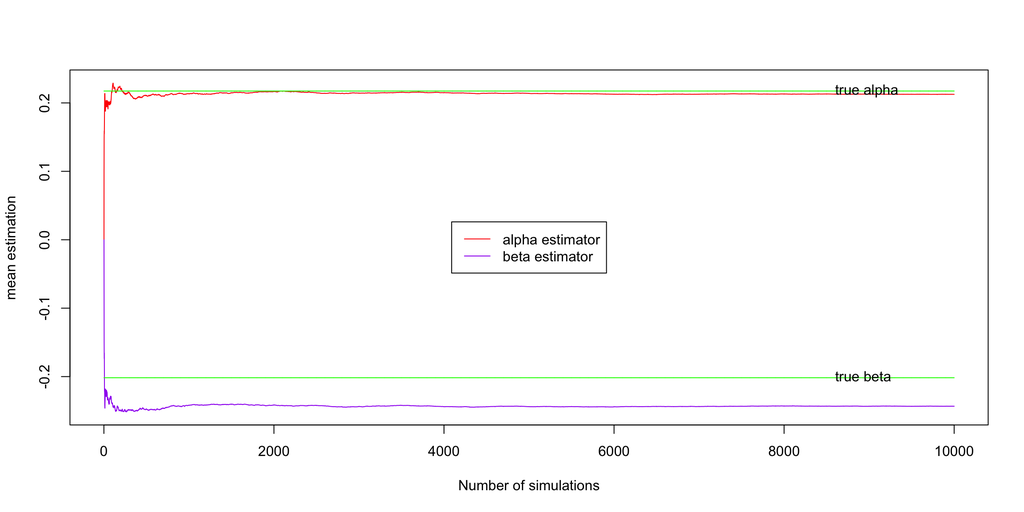

Figure 9: mean convergence

```r
parameter = infer.gibss(sample_500, c(0,0), c(1,1))
plot_mean(parameter, sample_500[3], sample_500[4]) #plot the convergence of the mean through simulation
```

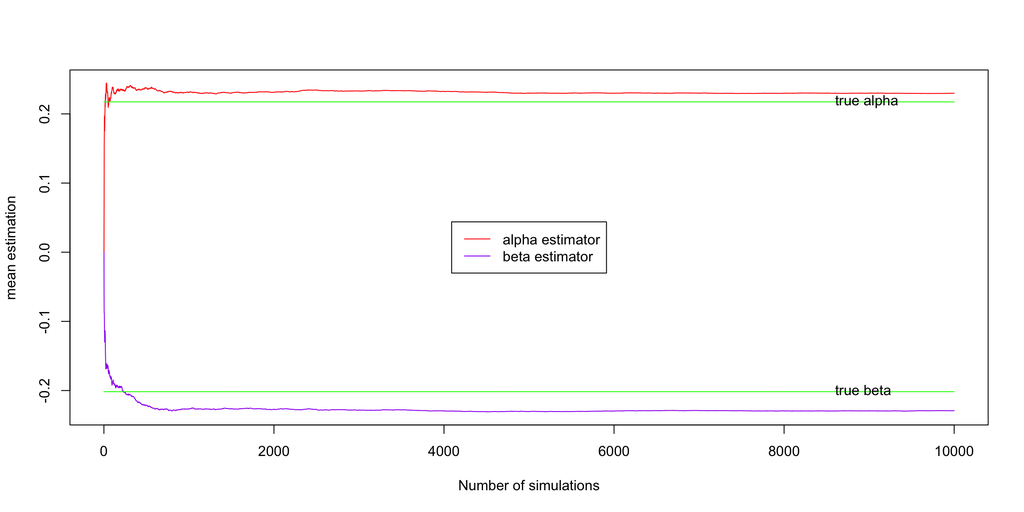

Figure 10: mean convergence

```r
parameter = infer.gibss(sample_500, c(5,5), c(2,2))
plot_mean(parameter, sample_500[3], sample_500[4]) #plot the convergence of the mean through simulation
```

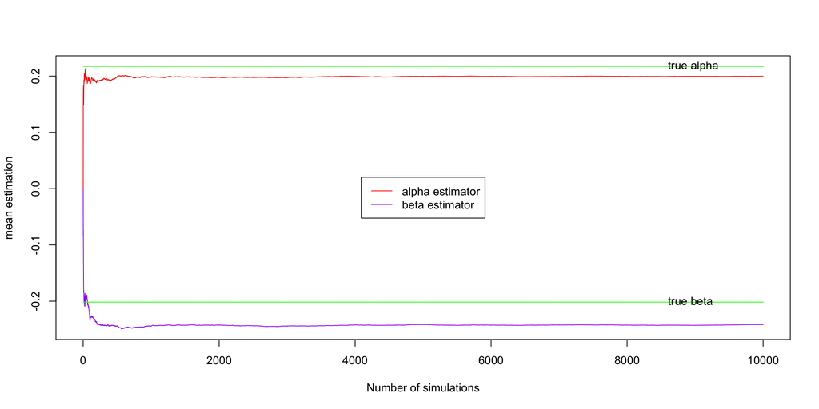

Figure 11: mean convergence

```r
parameter = infer.gibss(sample_500, c(-2,2), c(1,3))
plot_mean(parameter, sample_500[3], sample_500[4]) #plot the convergence of the mean through simulation
```

$\\$

9. Choose a simpler version of the model and check which type is more adequate for the data.

We choose the same probit model with conitnuous uniform variable X in [-1, 1]. We also ommit the $\epsilon$ variables. The model become :

$$P(Y=1|X=x)=\Phi(\alpha+\beta x) \\
X \text{~ }\mathcal{U}([-1,\,1]) \\
\alpha \text{~}\mathcal{N}(0,\,1) ~~~~~~
\beta \text{~}\mathcal{N}(0,\,1)$$
By ommiting the epsilon variable, we now have :
$$z|(\alpha, \beta), y, x\text{ ~ } y\mathcal{TN}(\alpha + \beta x,\,1, 0, \infty) + (1-y)\mathcal{TN}(\alpha + \beta x,\,1, -\infty, 0)$$
ie the variance of the truncated laws is 1 instead of 2. For the conditionnal law $(\alpha, \beta)|z,y,x$, we obtain the same result as previously by ommiting the factor $\frac{1}{2}$ for the mean and variance parameter :
$$p((\alpha, \beta)|z,y,x) \text{ ~ } \mathcal{N}(A^{-1}(\sum_{i=1}^n z_i ~~~\sum_{i=1}^n z_ix_i)^T,\,A^{-1}) ~~\text{ with } A=
\begin{pmatrix}
n+1 & \sum_{i=1}^nx_i \\
\sum_{i=1}^nx_i & \sum_{i=1}^nx_i^2+1
\end{pmatrix}$$

In addition to the gibbs estimator, we can now compute the maximum likelihood estimator (MLE). Indeed, without the previous unknown $\epsilon$ we have that :
$$L(\alpha, \beta)=\prod_{i=1}^n p(y_i|x_i,\alpha,\beta) = \prod_{i=1}^n \Phi(\alpha+\beta x_i)^{y_i} (1-\Phi(\alpha+\beta x_i))^{1-y_i}$$
By taking the log of L and then computing the gradient vector and hessian matrix of log(L), we can implemente the Newton’s method to compute the MLE $\alpha$ and $\beta$ by iterating :

$$\begin{pmatrix}
\alpha \\[1mm]
\beta \\[1mm]
\end{pmatrix}_{t+1} = \begin{pmatrix}
\alpha \\[1mm]
\beta \\[1mm]
\end{pmatrix}_{t}-Hess^{-1}(log(L(\alpha, \beta)_t))\nabla(log(L(\alpha, \beta)_t))$$
We can use the glm function in R that implement MLE for the most famous Generalized linear model (including the probit model)

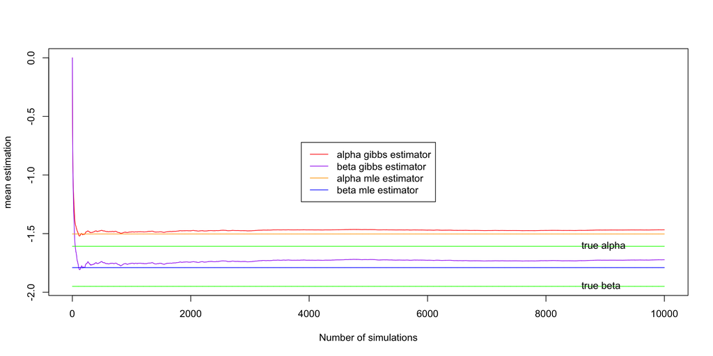

Figure 12: mean convergence

```r
set.seed(42) #to reproduce the result
sample = rgen(500, model='second')
x = sample[1,]
y = sample[2,]

parameter = infer.gibss(sample, c(0,0), c(1,1), model='second') #gibbs sample of alpha, beta
fit = glm(y~x, family=binomial(link = probit)) #mle model
alpha_mle = fit$coefficients[1] #mle of alpha
beta_mle = fit$coefficients[2] #mle of beta

plot_mean(parameter, sample[3], sample[4]) #plot the convergence of the gibbs mean through simulation
lines(rep(alpha_mle, length(parameter$value)/2), col='orange') #add the mle of alpha
lines(rep(beta_mle, length(parameter$value)/2), col='blue') #add the mle of beta
legend("center", legend=c("alpha gibbs estimator", "beta gibbs estimator", "alpha mle estimator", "beta mle estimator"), col=c("red", "purple", "orange", "blue"), lty=c(1,1,1,1))
```

We can also plot the density estimation of our sample with the Gibbs estimators.

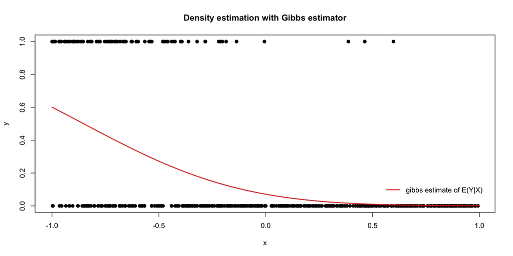

Figure 13: density

```r
plot(sample[1,], sample[2,], main='Density estimation with Gibbs estimator', pch=19, xlab='x', ylab='y') # plot x and y

lines(x=seq(-1, 1, length.out=500), y=pnorm(mean(parameter$value[parameter['label']=='alpha'])+mean(parameter$value[parameter['label']=='beta'])*seq(-1, 1, length.out=500)), col="red", lwd=2) #plot the estimate of E(y|x)

legend("bottomright", legend="gibbs estimate of E(Y|X)", col="red", bty='n', lty=1, lwd=2, inset=c(0.02, 0.08), cex=1)
```

```r
Sys.time()-time
```

```
## Time difference of 31.05999 secs
```